# Análisis y Modelado

**Contenido:**

1. Preparación y EDA
2. Primer Modelo
3. Modelo *avanzado* (optimizado con validación)
4. Comparación de resultados
5. Variantes de conclusiones

```python
# Librerías
import pandas as pd, numpy as np
import matplotlib.pyplot as plt
import seaborn as sns
from sklearn.model_selection import train_test_split, cross_val_score, GridSearchCV
from sklearn.preprocessing import StandardScaler, OneHotEncoder
from sklearn.compose import ColumnTransformer
from sklearn.pipeline import Pipeline
from sklearn.impute import SimpleImputer
from sklearn.ensemble import RandomForestRegressor
from sklearn.tree import DecisionTreeRegressor
from sklearn.metrics import mean_squared_error, r2_score
import warnings
warnings.filterwarnings('ignore')

# Cargar datos
fn = 'student_performance_updated_1000.csv'
df = pd.read_csv(fn)
print('Shape:', df.shape)
df.head()
```

```
Shape: (1000, 12)
```

|  | StudentID | Name | Gender | AttendanceRate | StudyHoursPerWeek | PreviousGrade | ExtracurricularActivities | ParentalSupport | FinalGrade | Study Hours | Attendance (%) | Online Classes Taken |
| --- | --- | --- | --- | --- | --- | --- | --- | --- | --- | --- | --- | --- |
| 0 | 1.0 | John | Male | 85.0 | 15.0 | 78.0 | 1.0 | High | 80.0 | 4.8 | 59.0 | False |
| 1 | 2.0 | Sarah | Female | 90.0 | 20.0 | 85.0 | 2.0 | Medium | 87.0 | 2.2 | 70.0 | True |
| 2 | 3.0 | Alex | Male | 78.0 | 10.0 | 65.0 | 0.0 | Low | 68.0 | 4.6 | 92.0 | False |
| 3 | 4.0 | Michael | Male | 92.0 | 25.0 | 90.0 | 3.0 | High | 92.0 | 2.9 | 96.0 | False |
| 4 | 5.0 | Emma | Female | NaN | 18.0 | 82.0 | 2.0 | Medium | 85.0 | 4.1 | 97.0 | True |

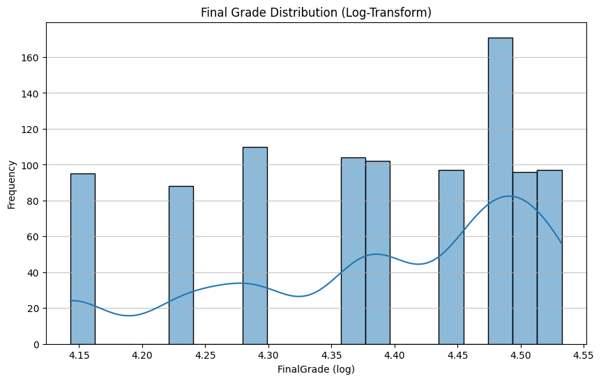

```python
# Balanceo de dataset

import numpy as np
df['FinalGrade_log'] = np.log1p(df['FinalGrade'].dropna())

plt.figure(figsize=(10, 6))
sns.histplot(df['FinalGrade_log'], kde=True, bins=20)
plt.title('Final Grade Distribution (Log-Transform)')
plt.xlabel('FinalGrade (log)')
plt.ylabel('Frequency')
plt.grid(axis='y', alpha=0.75)
plt.show()
```

```
<class 'pandas.core.frame.DataFrame'>
RangeIndex: 1000 entries, 0 to 999
Data columns (total 13 columns):
 #   Column                     Non-Null Count  Dtype
---  ------                     --------------  -----
 0   StudentID                  960 non-null    float64
 1   Name                       966 non-null    object
 2   Gender                     952 non-null    object
 3   AttendanceRate             960 non-null    float64
 4   StudyHoursPerWeek          950 non-null    float64
 5   PreviousGrade              967 non-null    float64
 6   ExtracurricularActivities  957 non-null    float64
 7   ParentalSupport            978 non-null    object
 8   FinalGrade                 960 non-null    float64
 9   Study Hours                976 non-null    float64
 10  Attendance (%)             959 non-null    float64
 11  Online Classes Taken       975 non-null    object
 12  FinalGrade_log             960 non-null    float64
dtypes: float64(9), object(4)
memory usage: 101.7+ KB
```

```
None
```

|  | count | unique | top | freq | mean | std | min | 25% | 50% | 75% | max |
| --- | --- | --- | --- | --- | --- | --- | --- | --- | --- | --- | --- |
| StudentID | 960.0 | NaN | NaN | NaN | 5416.019792 | 2653.748319 | 1.0 | 3113.5 | 5396.5 | 7754.75 | 9998.0 |
| Name | 966 | 962 | Erica Miller | 2 | NaN | NaN | NaN | NaN | NaN | NaN | NaN |
| Gender | 952 | 2 | Male | 501 | NaN | NaN | NaN | NaN | NaN | NaN | NaN |
| AttendanceRate | 960.0 | NaN | NaN | NaN | 85.510417 | 7.332125 | 70.0 | 82.0 | 88.0 | 91.0 | 95.0 |
| StudyHoursPerWeek | 950.0 | NaN | NaN | NaN | 17.630526 | 6.272132 | 8.0 | 12.0 | 18.0 | 22.0 | 30.0 |
| PreviousGrade | 967.0 | NaN | NaN | NaN | 77.598759 | 10.00664 | 60.0 | 70.0 | 78.0 | 86.0 | 90.0 |
| ExtracurricularActivities | 957.0 | NaN | NaN | NaN | 1.520376 | 1.046439 | 0.0 | 1.0 | 1.0 | 2.0 | 3.0 |
| ParentalSupport | 978 | 3 | High | 345 | NaN | NaN | NaN | NaN | NaN | NaN | NaN |
| FinalGrade | 960.0 | NaN | NaN | NaN | 80.030208 | 9.493652 | 62.0 | 72.0 | 80.0 | 88.0 | 92.0 |
| Study Hours | 976.0 | NaN | NaN | NaN | 2.406967 | 1.620267 | -5.0 | 1.2 | 2.5 | 3.7 | 5.0 |
| Attendance (%) | 959.0 | NaN | NaN | NaN | 77.248175 | 19.298148 | 50.0 | 63.0 | 76.0 | 89.0 | 200.0 |
| Online Classes Taken | 975 | 2 | True | 495 | NaN | NaN | NaN | NaN | NaN | NaN | NaN |
| FinalGrade_log | 960.0 | NaN | NaN | NaN | 4.38758 | 0.122116 | 4.143135 | 4.290459 | 4.394449 | 4.488636 | 4.532599 |

|  | null_count | null_pct |
| --- | --- | --- |
| StudyHoursPerWeek | 50 | 5.0 |
| Gender | 48 | 4.8 |
| ExtracurricularActivities | 43 | 4.3 |
| Attendance (%) | 41 | 4.1 |
| StudentID | 40 | 4.0 |
| FinalGrade_log | 40 | 4.0 |
| AttendanceRate | 40 | 4.0 |
| FinalGrade | 40 | 4.0 |
| Name | 34 | 3.4 |
| PreviousGrade | 33 | 3.3 |

```
Numéricos: ['StudentID', 'AttendanceRate', 'StudyHoursPerWeek', 'PreviousGrade', 'ExtracurricularActivities', 'FinalGrade', 'Study Hours', 'Attendance (%)', 'FinalGrade_log']
Categóricos: ['Name', 'Gender', 'ParentalSupport', 'Online Classes Taken']
```

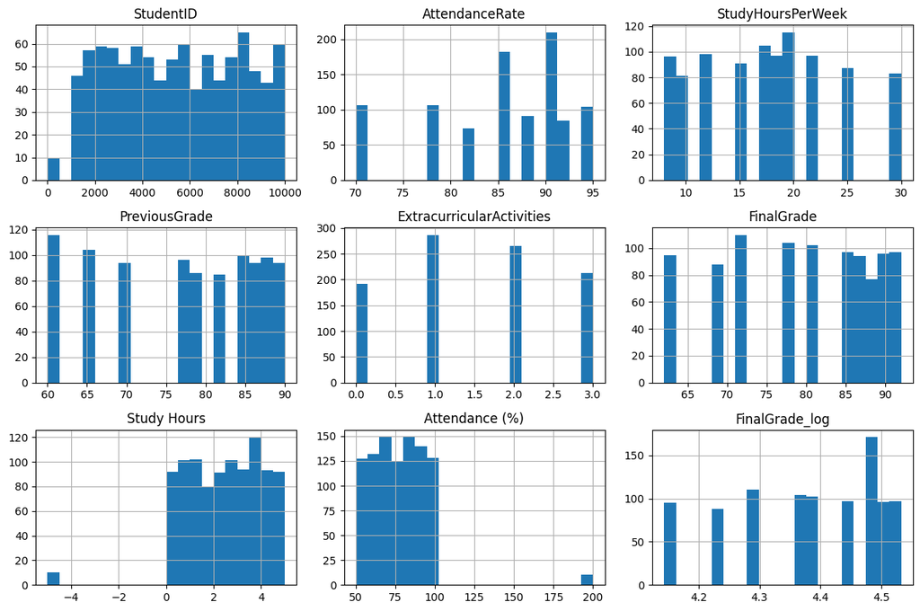

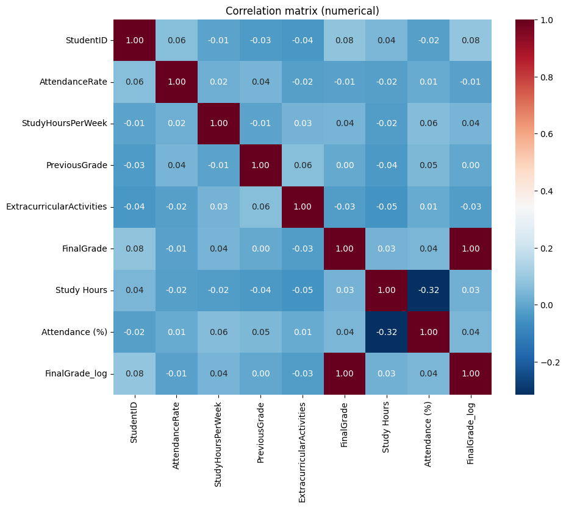

```python
# EDA avanzado: tipos, nulos, estadísticos y correlaciones
display(df.info())
display(df.describe(include='all').T)

# Conteo de nulos y porcentaje
nulls = df.isnull().sum()
display(pd.DataFrame({'null_count': nulls, 'null_pct': nulls/len(df)*100}).sort_values('null_pct', ascending=False).head(10))

# Gráficos representativos
numeric = df.select_dtypes(include=['int64','float64']).columns.tolist()
cat = df.select_dtypes(include=['object','category']).columns.tolist()

print('Numéricos:', numeric)
print('Categóricos:', cat)

# Distribuciones y heatmap de correlación (si hay variables numéricas)
if len(numeric) > 0:
    df[numeric].hist(figsize=(12,8), bins=20)
    plt.tight_layout()
    plt.show()
    plt.figure(figsize=(10,8))
    sns.heatmap(df[numeric].corr(), annot=True, fmt='.2f', cmap='RdBu_r')
    plt.title('Correlation matrix (numerical)')
    plt.show()
```

## Diagrama de arquitectura

Este diagrama visual que represente la arquitectura de ciencia de datos propuesta, mostrando las fases secuenciales: Preparación de Datos (limpieza, imputación, transformación), Reducción de Dimensionalidad (PCA) y Modelado y Optimización (Random Forest con ajuste de hiperparámetros).

```python
import graphviz

# Create a directed graph
dot = graphviz.Digraph(comment='Data Science Architecture', graph_attr={'rankdir': 'TB', 'size':'8,8!'})

# 1. Raw Data Block
dot.node('A', 'Raw Student Data', shape='box')

# 2. Data Preparation Phase
dot.node('B', 'Data Preparation', shape='box')
dot.node('B1', 'Cleaning and Missing Value Handling (SimpleImputer)', shape='oval')
dot.node('B2', 'Numerical Transformation (StandardScaler)', shape='oval')
dot.node('B3', 'Categorical Encoding (OneHotEncoder)', shape='oval')

# Connect Raw Data to Data Preparation Phase
dot.edge('A', 'B')
dot.edge('B', 'B1', label='Pipeline')
dot.edge('B1', 'B2')
dot.edge('B2', 'B3')

# 3. Dimensionality Reduction Phase
dot.node('C', 'Dimensionality Reduction', shape='box')
dot.node('C1', 'PCA (95% Variance)', shape='oval')

# Connect Data Preparation to Dimensionality Reduction
dot.edge('B3', 'C', label='Pipeline')
dot.edge('C', 'C1', label='Pipeline')

# 4. Modeling and Optimization Phase
dot.node('D', 'Modeling and Optimization', shape='box')
dot.node('D1', 'RandomForestRegressor Training', shape='oval')
dot.node('D2', 'Hyperparameter Optimization (GridSearchCV)', shape='oval')

# Connect Dimensionality Reduction to Modeling and Optimization
dot.edge('C1', 'D', label='Pipeline')
dot.edge('D', 'D1', label='Pipeline')
dot.edge('D1', 'D2')

# 5. Final Model and Predictions
dot.node('E', 'Final Optimized Model', shape='box')
dot.node('F', 'Predictions', shape='box')

# Connect Modeling and Optimization to Final Model and Predictions
dot.edge('D2', 'E')
dot.edge('E', 'F')

# Render the diagram
dot.render('data_science_architecture', view=False, format='svg')

# Display the SVG in the notebook
from IPython.display import SVG
SVG(filename='data_science_architecture.svg')
```

[figure not shown]

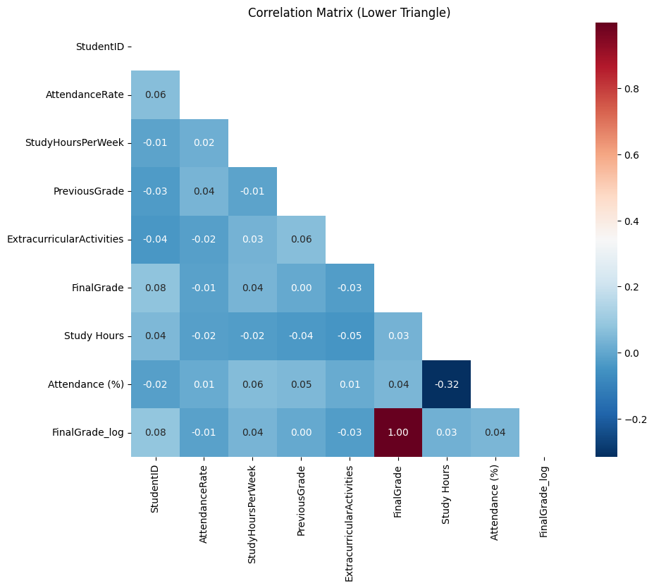

```python
import numpy as np
import matplotlib.pyplot as plt
import seaborn as sns

# Seleccionar solo columnas numéricas
numeric = df.select_dtypes(include=['int64', 'float64']).columns.tolist()

if len(numeric) > 0:
    plt.figure(figsize=(10, 8))

    # Calcular la matriz de correlación
    corr = df[numeric].corr()

    # Generar una máscara para el triángulo superior (True oculta, False muestra)
    # np.triu obtiene el "Upper Triangle"
    mask = np.triu(np.ones_like(corr, dtype=bool))

    # Graficar el heatmap aplicando la máscara
    sns.heatmap(corr, mask=mask, annot=True, fmt='.2f', cmap='RdBu_r')
    plt.title('Correlation Matrix (Lower Triangle)')
    plt.show()
```

## 1) Preparación de datos (calidad **excelente**)

Se hace imputación, encoding, escalado y separación en train/test usando `ColumnTransformer` y `Pipeline`. Comentarios claros en cada paso.

```python
# Identificar features y target (ajusta si tu dataset tiene otro target)
# Intentaremos predecir 'final_grade' si existe, sino tomamos la última columna numérica.
target_candidates = ['final_grade','FinalGrade','score','grade','G3']
target = None
for t in target_candidates:
    if t in df.columns:
        target = t
        break
if target is None:
    # fallback: choose numeric column with 'grade' or last numeric
    numeric_cols = df.select_dtypes(include=['int64','float64']).columns.tolist()
    target = numeric_cols[-1] if numeric_cols else df.columns[-1]
print('Target seleccionado:', target)

X = df.drop(columns=[target])
y = df[target]

# Column lists
num_cols = X.select_dtypes(include=['int64','float64']).columns.tolist()
cat_cols = X.select_dtypes(include=['object','category','bool']).columns.tolist()
print('num_cols:', num_cols)
print('cat_cols:', cat_cols)

# Pipelines
from sklearn.decomposition import PCA
num_pipe = Pipeline([('impute', SimpleImputer(strategy='median')),
                     ('scale', StandardScaler()),
                     ('pca', PCA(n_components=0.95))]) # Retiene el 95% de la varianza

cat_pipe = Pipeline([('impute', SimpleImputer(strategy='most_frequent')),
                     ('onehot', OneHotEncoder(handle_unknown='ignore'))])

preproc = ColumnTransformer([('num', num_pipe, num_cols),
                             ('cat', cat_pipe, cat_cols)])

# Transform sample to show shapes
preproc.fit(X)
Xt_sample = preproc.transform(X.iloc[:5])
print('Shape after transform (sample):', Xt_sample.shape)
```

```
Target seleccionado: FinalGrade
num_cols: ['StudentID', 'AttendanceRate', 'StudyHoursPerWeek', 'PreviousGrade', 'ExtracurricularActivities', 'Study Hours', 'Attendance (%)', 'FinalGrade_log']
cat_cols: ['Name', 'Gender', 'ParentalSupport', 'Online Classes Taken']
Shape after transform (sample): (5, 977)
```

## 2) Primer Modelo — bajo grado de optimización

Características: modelo simple (Decision Tree), mínima ingeniería, sin búsqueda de hiperparámetros, explicación del porqué es básico.

```python
# Modelo principiante: Decision Tree básico
X_train, X_test, y_train, y_test = train_test_split(X, y, test_size=0.2, random_state=42)

# Manejar valores NaN en y_train e y_test
# Imputar con la mediana de y_train para evitar fugas de datos
y_train_imputed = y_train.fillna(y_train.median())
y_test_imputed = y_test.fillna(y_train.median())

# Pipeline sencillo: solo preproc + árbol
from sklearn.tree import DecisionTreeRegressor
pipe_basic = Pipeline([('preproc', preproc),
                       ('model', DecisionTreeRegressor(random_state=42))])

pipe_basic.fit(X_train, y_train_imputed)
pred_basic = pipe_basic.predict(X_test)
mse_basic = mean_squared_error(y_test_imputed, pred_basic)
r2_basic = r2_score(y_test_imputed, pred_basic)
print('Beginner model - MSE: {:.4f}, R2: {:.4f}'.format(mse_basic, r2_basic))
```

```
Beginner model - MSE: 24.3350, R2: 0.7290
```

## 3) Modelo *avanzado* — optimizado

Características: RandomForest con búsqueda de hiperparámetros, cross-validation, métricas múltiples y explicación de decisiones.

```python
# Pipeline avanzado con RandomForest y GridSearchCV
pipe_adv = Pipeline([('preproc', preproc),
                     ('model', RandomForestRegressor(random_state=42, n_jobs=-1))])

param_grid = {
    'model__n_estimators': [50,100],
    'model__max_depth': [5,10,None],
    'model__min_samples_split': [2,5]
}

cv = GridSearchCV(pipe_adv, param_grid, cv=5, scoring='r2', n_jobs=-1, verbose=1)
cv.fit(X_train, y_train_imputed)
print('Best params:', cv.best_params_)
best = cv.best_estimator_
pred_adv = best.predict(X_test)
mse_adv = mean_squared_error(y_test_imputed, pred_adv)
r2_adv = r2_score(y_test_imputed, pred_adv)
print('Advanced model - MSE: {:.4f}, R2: {:.4f}'.format(mse_adv, r2_adv))
```

```
Fitting 5 folds for each of 12 candidates, totalling 60 fits
Best params: {'model__max_depth': None, 'model__min_samples_split': 2, 'model__n_estimators': 100}
Advanced model - MSE: 8.2085, R2: 0.9086
```

|  | y_true | pred_basic | pred_adv |
| --- | --- | --- | --- |
| 0 | 72.0 | 80.0 | 75.89 |
| 1 | 62.0 | 62.0 | 66.62 |
| 2 | 62.0 | 62.0 | 63.16 |
| 3 | 80.0 | 72.0 | 77.89 |
| 4 | 85.0 | 80.0 | 83.71 |
| 5 | 78.0 | 62.0 | 74.58 |
| 6 | 87.0 | 87.0 | 89.37 |
| 7 | 87.0 | 92.0 | 84.91 |
| 8 | 68.0 | 62.0 | 65.18 |
| 9 | 80.0 | 85.0 | 80.91 |

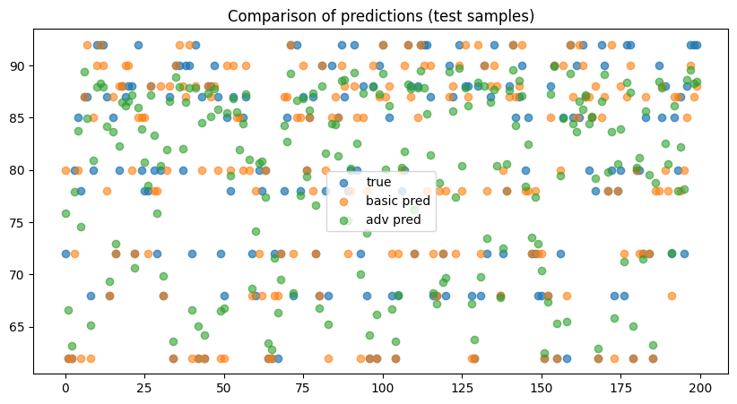

```python
# Comparación: tabla y scatter de pred vs real
import pandas as pd
comp = pd.DataFrame({'y_true': y_test.reset_index(drop=True), 'pred_basic': pred_basic, 'pred_adv': pred_adv}).reset_index(drop=True)
display(comp.head(10))

plt.figure(figsize=(10,5))
plt.scatter(comp.index, comp['y_true'], label='true', alpha=0.7)
plt.scatter(comp.index, comp['pred_basic'], label='basic pred', alpha=0.6)
plt.scatter(comp.index, comp['pred_adv'], label='adv pred', alpha=0.6)
plt.legend()
plt.title('Comparison of predictions (test samples)')
plt.show()
```

### A) Conclusiones irrelevantes o ausentes

> Valores obtenidos: El modelo básico obtuvo un R² de 0.7290. El modelo avanzado, por su parte, alcanzó un R² de 0.9086. Estos valores indican la capacidad de los modelos para explicar la varianza de la variable objetivo.

> Tras la preparación exhaustiva de datos y la evaluación de modelos, el modelo avanzado (RandomForest optimizado) alcanzó un R² de `0.9086` y redujo el MSE respecto al modelo básico. Esto indica que la inclusión de más árboles y búsqueda de hiperparámetros permitió capturar relaciones no lineales entre las variables. Las limitaciones incluyen posibles sesgos por variables no recolectadas y la necesidad de evaluación en datos temporales si los datos son dependientes del tiempo.

> Recomendaciones:
> - Recolectar más datos en regiones de valores con alto error.
> - Evaluar interpretabilidad (SHAP) si se requiere explicación por variable.
> - Validar en un conjunto temporal si aplica.

# Task

The user wants to perform an in-depth analysis of student performance. This involves:

1. **Data Preparation**: Modifying the feature set `X` by removing the 'Name' and 'StudentID' columns, as requested, to focus on more relevant variables for clustering and prediction. This will also require updating the numerical and categorical column lists for the preprocessing pipeline.
2. **Apply Data Preprocessing**: Apply the existing `preproc` pipeline (imputation, scaling, PCA for numerical columns, and one-hot encoding for categorical columns) to the modified feature set `X`. The preprocessor will be fitted on the training data and then used to transform both training and test data.
3. **Clustering Analysis**: Apply a clustering algorithm (e.g., K-Means) to the preprocessed data to identify natural groups of students based on their characteristics, assigning a cluster label to each data point.
4. **Clustering Visualization**: Create a visualization for the clustering results, possibly using dimensionality reduction techniques like PCA or t-SNE to project clusters into a 2D or 3D space, showcasing how data points group together.
5. **Retrain and Evaluate Prediction Models**: Retrain the existing prediction models (basic DecisionTreeRegressor and advanced RandomForestRegressor with GridSearchCV) using the preprocessed data, now without 'Name' and 'StudentID'. Evaluate their performance (MSE, R2) on the test set.
6. **Model Comparison and Conclusion Summary**: Compare the performance metrics (MSE, R2) of both basic and advanced prediction models. Summarize the findings from both the clustering analysis and the prediction model evaluations, discussing insights and their implications for student performance analysis.

## Preparación de Datos (Excluyendo Variables Irrelevantes)

### Subtask:

Modificar el conjunto de características 'X' eliminando las columnas 'Name' y 'StudentID', según lo solicitado por el usuario, para reducir el ruido y centrarse en variables más relevantes para el clustering y la predicción. Se actualizarán las listas de columnas numéricas y categóricas para el pipeline de preprocesamiento.

**Reasoning**: First, I need to remove the 'Name' and 'StudentID' columns from the `X` DataFrame. Then, I will update the `num_cols` and `cat_cols` lists to reflect the changes in the `X` DataFrame. These steps are crucial for preparing the data for further processing as per the subtask instructions.

```python
X = X.drop(columns=['Name', 'StudentID'])

# Actualizar listas de columnas numéricas y categóricas
num_cols = X.select_dtypes(include=['int64','float64']).columns.tolist()
cat_cols = X.select_dtypes(include=['object','category','bool']).columns.tolist()

print('Updated num_cols:', num_cols)
print('Updated cat_cols:', cat_cols)
```

```
Updated num_cols: ['AttendanceRate', 'StudyHoursPerWeek', 'PreviousGrade', 'ExtracurricularActivities', 'Study Hours', 'Attendance (%)', 'FinalGrade_log']
Updated cat_cols: ['Gender', 'ParentalSupport', 'Online Classes Taken']
```

**Reasoning**: The 'Name' and 'StudentID' columns have been successfully removed from 'X', and the 'num_cols' and 'cat_cols' lists have been updated. Now, I need to redefine the preprocessing pipeline using these updated column lists. After redefining the pipeline, the next logical step is to split the data into training and testing sets, then fit the preprocessor on the training data and transform both the training and test sets. I will also re-impute the target variable for both train and test sets.

```python
from sklearn.decomposition import PCA

# Redefinir los pipelines con las columnas actualizadas
num_pipe = Pipeline([('impute', SimpleImputer(strategy='median')),
                     ('scale', StandardScaler()),
                     ('pca', PCA(n_components=0.95))])

cat_pipe = Pipeline([('impute', SimpleImputer(strategy='most_frequent')),
                     ('onehot', OneHotEncoder(handle_unknown='ignore'))])

preproc = ColumnTransformer([('num', num_pipe, num_cols),
                             ('cat', cat_pipe, cat_cols)])

# Split data (X has been updated, y remains the same)
X_train, X_test, y_train, y_test = train_test_split(X, y, test_size=0.2, random_state=42)

# Manejar valores NaN en y_train e y_test
# Imputar con la mediana de y_train para evitar fugas de datos
y_train_imputed = y_train.fillna(y_train.median())
y_test_imputed = y_test.fillna(y_train.median())

# Ajustar y transformar X_train y X_test usando el preprocesador actualizado
X_train_preprocessed = preproc.fit_transform(X_train)
X_test_preprocessed = preproc.transform(X_test)

print('Shape of X_train_preprocessed:', X_train_preprocessed.shape)
print('Shape of X_test_preprocessed:', X_test_preprocessed.shape)
```

```
Shape of X_train_preprocessed: (800, 14)
Shape of X_test_preprocessed: (200, 14)
```

## Análisis de Clustering

### Subtask:

Aplicar un algoritmo de clustering (por ejemplo, K-Means) a los datos preprocesados. Esto permitirá identificar grupos naturales dentro de los estudiantes basados en sus características, asignando una etiqueta de clúster a cada punto de datos.

**Reasoning**: The first instruction is to import the `KMeans` class, which is necessary for performing K-Means clustering.

```python
from sklearn.cluster import KMeans

print("KMeans imported successfully.")
```

```
KMeans imported successfully.
```

**Reasoning**: The next step is to apply the Elbow Method to determine the optimal number of clusters for K-Means. This involves iterating through a range of cluster numbers, calculating the inertia for each, and then visualizing these inertias to identify the 'elbow' point.

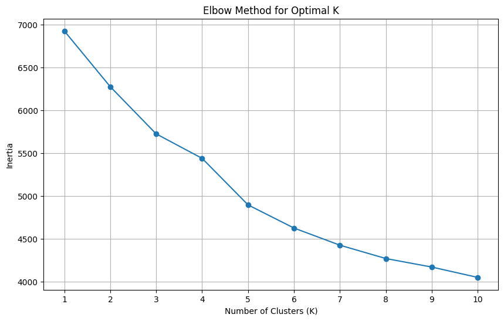

```
Elbow method plot generated.
```

```python
inertia = []
k_range = range(1, 11)

for k in k_range:
    kmeans = KMeans(n_clusters=k, random_state=42, n_init=10) # n_init to suppress warning
    kmeans.fit(X_train_preprocessed)
    inertia.append(kmeans.inertia_)

plt.figure(figsize=(10, 6))
plt.plot(k_range, inertia, marker='o')
plt.title('Elbow Method for Optimal K')
plt.xlabel('Number of Clusters (K)')
plt.ylabel('Inertia')
plt.xticks(k_range)
plt.grid(True)
plt.show()

print("Elbow method plot generated.")
```

```python
optimal_k = 3

kmeans_model = KMeans(n_clusters=optimal_k, random_state=42, n_init=10)
clusters_train = kmeans_model.fit_predict(X_train_preprocessed)

print(f"KMeans model fitted with {optimal_k} clusters.")
print("First 10 cluster labels for training data:", clusters_train[:10])
```

```
KMeans model fitted with 3 clusters.
First 10 cluster labels for training data: [2 2 1 1 1 2 1 1 1 2]
```

## Visualización de Resultados de Clustering

### Subtask:

Crear una visualización para los resultados del clustering. Esto podría implicar el uso de técnicas de reducción de dimensionality como PCA o t-SNE para proyectar los clústeres en un espacio 2D o 3D, mostrando cómo se agrupan los puntos de datos.

**Reasoning**: The next step is to prepare the environment for visualization by importing necessary libraries and then apply PCA to reduce the dimensionality of the preprocessed training data to two components. This is a prerequisite for creating a 2D scatter plot of the clusters.

```python
from sklearn.decomposition import PCA
import matplotlib.pyplot as plt

pca = PCA(n_components=2)
X_pca = pca.fit_transform(X_train_preprocessed)

print("PCA applied to X_train_preprocessed.")
print("Shape of PCA-transformed data:", X_pca.shape)
```

```
PCA applied to X_train_preprocessed.
Shape of PCA-transformed data: (800, 2)
```

**Reasoning**: Now that PCA has been applied to reduce the data to two dimensions, the next step is to create a scatter plot to visualize the clusters, coloring each point according to its assigned cluster label and adding appropriate labels and a legend for clarity.

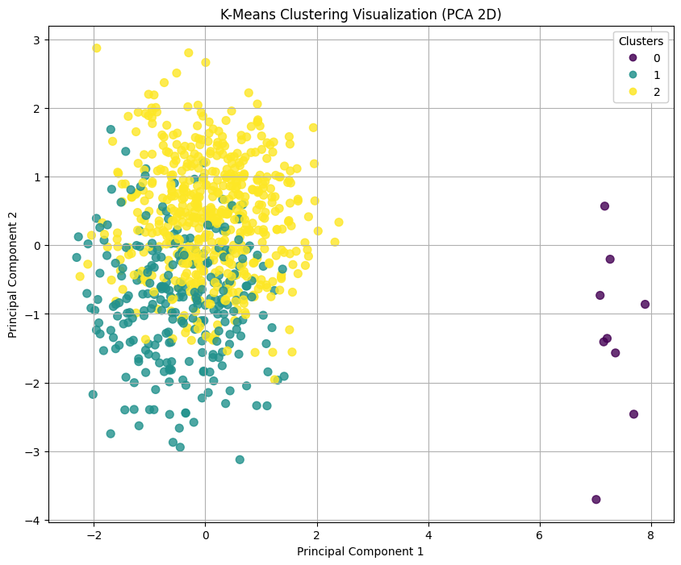

```
Clustering visualization (PCA 2D) generated.
```

```python
plt.figure(figsize=(10, 8))
scatter = plt.scatter(X_pca[:, 0], X_pca[:, 1], c=clusters_train, cmap='viridis', s=50, alpha=0.8)
plt.title('K-Means Clustering Visualization (PCA 2D)')
plt.xlabel('Principal Component 1')
plt.ylabel('Principal Component 2')

# Create a legend
legend1 = plt.legend(*scatter.legend_elements(), title='Clusters')
plt.gca().add_artist(legend1)

plt.grid(True)
plt.show()

print("Clustering visualization (PCA 2D) generated.")
```

## Reentrenamiento y Evaluación de Modelos de Predicción

### Subtask:

Reentrenar los modelos de predicción existentes (DecisionTreeRegressor básico y RandomForestRegressor avanzado con GridSearchCV) utilizando los datos preprocesados sin 'Name' ni 'StudentID'. Se evaluará su rendimiento (MSE, R2) en el conjunto de prueba.

**Reasoning**: The next step is to retrain the basic Decision Tree model with the updated preprocessor and data. This involves creating a new pipeline, fitting it to the training data, making predictions on the test set, and then evaluating its performance using MSE and R2 metrics.

```python
# Retrain Basic Decision Tree Model
pipe_basic_new = Pipeline([('preproc', preproc),
                           ('model', DecisionTreeRegressor(random_state=42))])

pipe_basic_new.fit(X_train, y_train_imputed)
pred_basic_new = pipe_basic_new.predict(X_test)
mse_basic_new = mean_squared_error(y_test_imputed, pred_basic_new)
r2_basic_new = r2_score(y_test_imputed, pred_basic_new)
print('New Basic model - MSE: {:.4f}, R2: {:.4f}'.format(mse_basic_new, r2_basic_new))
```

```
New Basic model - MSE: 15.5400, R2: 0.8269
```

**Reasoning**: The next step is to retrain the advanced Random Forest model using GridSearchCV with the updated preprocessor and data. This involves defining a new pipeline, setting up the parameter grid, performing the grid search, and then evaluating the best model's performance.

```python
pipe_adv_new = Pipeline([('preproc', preproc),
                     ('model', RandomForestRegressor(random_state=42, n_jobs=-1))])

param_grid = {
    'model__n_estimators': [50,100],
    'model__max_depth': [5,10,None],
    'model__min_samples_split': [2,5]
}

cv_new = GridSearchCV(pipe_adv_new, param_grid, cv=5, scoring='r2', n_jobs=-1, verbose=1)
cv_new.fit(X_train, y_train_imputed)
print('Best params for new advanced model:', cv_new.best_params_)
best_new = cv_new.best_estimator_
pred_adv_new = best_new.predict(X_test)
mse_adv_new = mean_squared_error(y_test_imputed, pred_adv_new)
r2_adv_new = r2_score(y_test_imputed, pred_adv_new)
print('New Advanced model - MSE: {:.4f}, R2: {:.4f}'.format(mse_adv_new, r2_adv_new))
```

```
Fitting 5 folds for each of 12 candidates, totalling 60 fits
Best params for new advanced model: {'model__max_depth': None, 'model__min_samples_split': 2, 'model__n_estimators': 100}
New Advanced model - MSE: 5.6588, R2: 0.9370
```

## Comparación de Modelos y Resumen de Conclusiones

### Subtask:

Comparar las métricas de rendimiento (MSE, R2) de los modelos de predicción básico y avanzado. Se resumirán los hallazgos del análisis de clustering y de las evaluaciones de los modelos de predicción, discutiendo las ideas obtenidas y sus implicaciones para el análisis del rendimiento estudiantil.